# Introduction to Machine Learning in the Digital Humanities - Day 3

# Today’s class

- Unsupervised learning
- Latent Dirchlet Allocation
- Heirarchical Clustering

# Topic Modelling - Latent Dirchlet Allocation (LDA)

- LDA is one of the “simplest” topic models.
- A topic is defined as having words associated with that topic with high probability. For example, genetics topic has words about genetics with high probability.

## LDA Assumptions

- The model assumes that these topics are generated before the documents.
- Each document in the collection shares the same topics.
- Each document exhibits the topics in different proportion.
- Each word in each document belongs to one of the topics.

## LDA Model

# Unsupervised Learning

- In supervised learning we have a set of features and a response. The goal is to predict the response based on the features.
- In unsupervised learning we only have a set of features.
- The goal is usually to discover interesting things about the features.
- For example, an informative vizualization or meaningful subgroups among the observations.
- Unsupervised learning is much more challenging since it’s more subjective.
- There is usually (not including topic modelling) no simple goal such as predicting the response.

## Heirarchical Clustering

- Clustering techniques are used to find subgroups or clusters in a data set.
- The idea is to partition the observations into groups so that the observations within a group are similar, and the observations in different groups are different from each other.
- This requires defining *similar*. This is usually defined as Euclidean distance.
- The term heirarchical refers to the fact that clusters obtained by cutting the dendrogram at a given height are necessarily nested within the clusters obtained by cutting the dendrogram at any greater height.

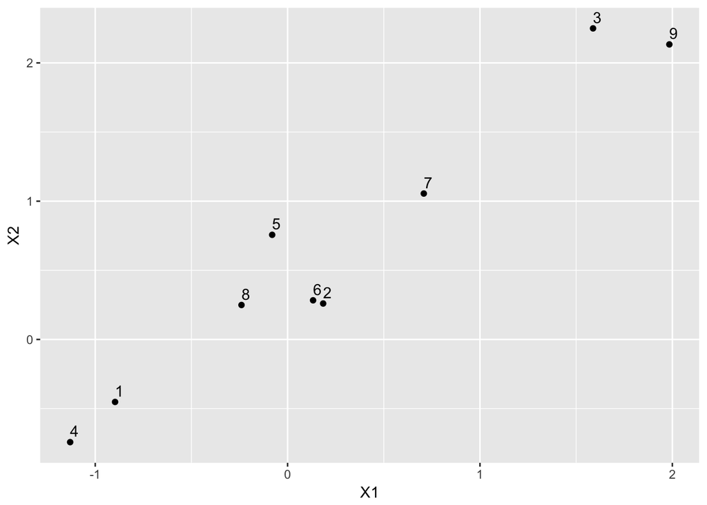

[figure not shown]

```
## # A tibble: 9 x 3
##     obs      X1     X2
##   <int>   <dbl>  <dbl>
## 1     1 -0.897  -0.452
## 2     2  0.185   0.260
## 3     3  1.59    2.25
## 4     4 -1.13   -0.743
## 5     5 -0.0803  0.757
## 6     6  0.132   0.283
## 7     7  0.708   1.06
## 8     8 -0.240   0.249
## 9     9  1.98    2.13
```

[output not shown]

# How to interpret a dendogram

(Reference, James et.al., An Introduction to Statistical Learning) - Each leaf represents one of the nine observations. - As we move up the tree some leaves fuse into branches. These correspond to observations that are similar to each other. - In fact, this statement can be made precise: for any two observations, we can look for the point in the tree where branches containing those two observations are first fused. The height of this fusion, as measured on the vertical axis, indicates how different the two observations are. Thus, observations that fuse at the very bottom of the tree are quite similar to each other, whereas observations that fuse close to the top of the tree will tend to be quite different.

- If the dendogram is cut at height 3.5 then this results in two distinct clusters.
- If the dendogram is cut at height 2.5 then this results in three distinct clusters.
- Conclusions about similarity are based on the location on the vertical axis where branches containing the observations are first fused.

```r
hgwells <- gutenberg_download(c(35, 36, 5230, 159,34962,1743))

book_words <- hgwells %>%
  unnest_tokens(word, text) %>% count(gutenberg_id, word, sort = TRUE) %>% ungroup()

total_words <- book_words %>% group_by(gutenberg_id) %>% summarize(total = sum(n))

book_words <- left_join(book_words,total_words)
book_words
```

```
## # A tibble: 38,306 x 4
##    gutenberg_id word      n total
##           <int> <chr> <int> <int>
##  1           36 the    4793 60513
##  2         1743 the    3696 73932
##  3         5230 the    3323 49168
##  4         1743 and    3145 73932
##  5          159 the    3034 44281
##  6        34962 the    2887 48079
##  7           36 and    2504 60513
##  8           36 of     2301 60513
##  9           35 the    2260 32653
## 10         1743 of     2219 73932
## # ... with 38,296 more rows
```

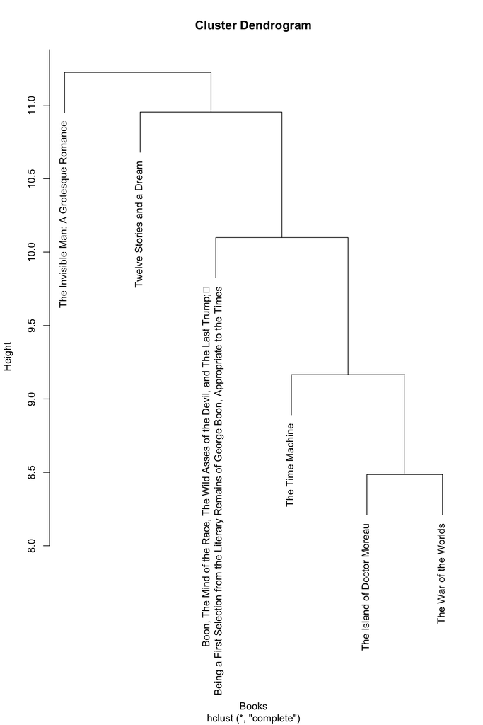

```r
book_titles <- gutenberg_metadata %>% filter(gutenberg_id == 35 |gutenberg_id == 36|gutenberg_id ==5230|gutenberg_id == 159|gutenberg_id == 34962|gutenberg_id == 1743) %>% select(gutenberg_id,title)

book_words <- left_join(book_words,book_titles)

book_words <- book_words %>% bind_tf_idf(word, title, n)



book_words_high <- book_words %>%
        select(-total) %>%
        arrange(desc(tf_idf)) %>% slice(1:50)

dtm_wells <- book_words_high %>% cast_tdm(title,word,n)

wells_matrix <- as.matrix(dtm_wells)

d <-dist(scale(wells_matrix))

groups <- hclust(d,method = "complete")

plot(groups,size=0.5,xlab = "Books")
```

# Questions

- What does it mean for two books being similar?
- Do these groups make sense?
- What is the interpretation of these groups?